# 04. Model fitting and checking assumptions

COADDS24.1F-011/030/032

# Loading libraries

```r
source("functions.R")

required_packages <- c("ggplot2", "lmtest", "car")

for (package in required_packages) {
  if (!suppressPackageStartupMessages(require(package, character.only = TRUE))) {
    install.packages(package)
  }
  suppressPackageStartupMessages(library(package, character.only = TRUE))
  cat("loaded package:", package,"\n")
}
```

```
## loaded package: ggplot2
## loaded package: lmtest
## loaded package: car
```

# Analysis of the fitted model

```r
df <- read.csv("../data/06_scaled.csv", header=TRUE)

model <- lm(temperature ~ humidity + light_level + uv_level, data = df)

print(summary(model, diagnostics=TRUE))
```

```
##
## Call:
## lm(formula = temperature ~ humidity + light_level + uv_level,
##     data = df)
##
## Residuals:
##       Min        1Q    Median        3Q       Max
## -0.170796 -0.041737 -0.000319  0.043780  0.272123
##
## Coefficients:
##              Estimate Std. Error t value Pr(>|t|)
## (Intercept)  0.724744   0.009842  73.636  < 2e-16 ***
## humidity    -0.888851   0.009718 -91.469  < 2e-16 ***
## light_level -0.002041   0.004844  -0.421    0.674
## uv_level     0.144616   0.024062   6.010 2.12e-09 ***
## ---
## Signif. codes:  0 '***' 0.001 '**' 0.01 '*' 0.05 '.' 0.1 ' ' 1
##
## Residual standard error: 0.0611 on 2552 degrees of freedom
## Multiple R-squared:  0.8071, Adjusted R-squared:  0.8069
## F-statistic:  3560 on 3 and 2552 DF,  p-value: < 2.2e-16
```

## Summary Interpretation

- The MLR model is represented as
  $$\hat{Y} = \beta_0 + \beta_1 X_1 + \beta_2 X_2 +
  \beta_3 X_3 + \epsilon$$
  where,
  $\hat{Y}$ = Predicted Temperature
  $\beta_0$ = y intercept term
  $X_1, X_2, X_3$ = independent variables (Humidity,Light intensity,UV intensity)
  $\beta_1, \beta_2, \beta_3$ = regression coefficients of Humidity,Light intensity,UV intensity
  $\epsilon$ = error term/residuals
- Humidity has a $p-value < 0.001$ (Signif.code: ‘***’ [0, 0.001]). therefore the humidity variable shows a high statistically significant relationship with temperature at the 5% significance level.
- null hypothesis for $X_1$ predictor is rejected at 95% confidence level, accept $𝐻_1: \beta_1 ≠ 0$
- light_level has a $p-value > 0.05$ (Signif.code:’ ’[0.05, 1]). Therefore, the light_level variable does not show a statistically significant relationship with temperature at the 5% significance level.
- null hypothesis for $X_2$ predictor is accepted at 95% confidence level, accept $𝐻_0: \beta_2 = 0$
- uv_level has a $p-value < 0.001$ (Signif.code: ‘***’ [0, 0.001]). therefore the uv_level variable shows a high statistically significant relationship with temperature at the 5% significance level.
- null hypothesis for $X_3$ predictor is rejected at 95% confidence level, accept $𝐻_1: \beta_3 ≠ 0$
- Overall null hypothesis is rejected $(H_0: \beta_0 = \beta_1 = \beta_2 = \beta_3 = 0)$. accept alternate hypothesis

### Conclusion

Humidity and uv_level variables show high statistically significant relationships with temperature while light_level does not show a statistically significant relationship with temperature at the 5% significance level.
$$H_1: \exists \beta_i
\neq 0, \text{ for at least one } i \in \{1,2,3\}$$
.

Therefore the final regression model is interpreted as
$$\hat{Y} = (0.724744) + (-0.888851) X_1 +
(-0.002041) X_2 + (0.144616) X_3 \pm (0.0611)$$

## Residuals vs Fitted Plot (Linearity)

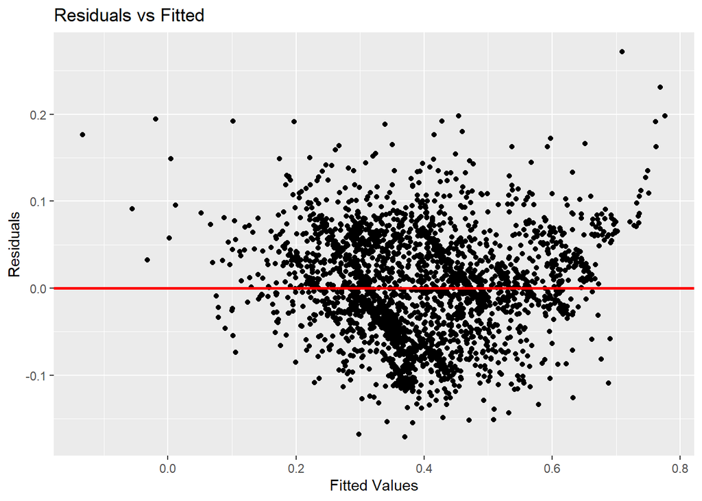

```r
ggplot_data <- data.frame(fitted = model$fitted.values, residuals = model$residuals)
p <- ggplot(ggplot_data, aes(x = fitted, y = residuals)) +
  geom_point() +
  geom_hline(yintercept = 0, color = "red", linewidth = 1) +
  labs(x = "Fitted Values", y = "Residuals", title = "Residuals vs Fitted")

ggsave("../figures/04_residuals_vs_fitted_plot.png", plot = p, width = 6, height = 4, dpi = 300)
print(p)
```

### Objective

to check if there is a linear relationship between predictors and the response (linearity).

## Durbin-Watson Test (Independence)

```r
lmtest::dwtest(model)
```

```
##
##  Durbin-Watson test
##
## data:  model
## DW = 1.9874, p-value = 0.3743
## alternative hypothesis: true autocorrelation is greater than 0
```

### Objective

to check if the error terms are independent or if they exhibit a pattern over time (autocorrelation)

- $H_0$ - residuals have no autocorrelation
- $H_1$ - true autocorrelation is greater than 0

### Conclusion

$H_0$ is accepted at $\alpha = 0.05$ (95% confidence level) since $p-value > 0.05$, residuals have no autocorrelation.

## QQ Plot and Shapiro-Wilk Test for Residuals (Normality)

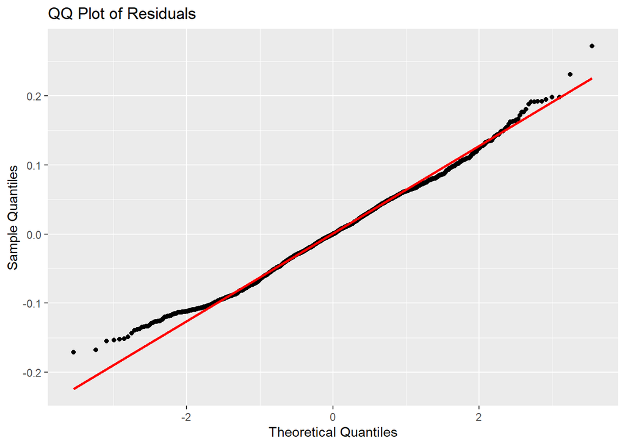

```r
residuals_df <- data.frame(residuals = model$residuals)
p <- ggplot(residuals_df, aes(sample = residuals)) +
  geom_qq() +
  geom_qq_line(color = "red", linewidth = 1) +
  labs(title = "QQ Plot of Residuals", x = "Theoretical Quantiles", y = "Sample Quantiles")

ggsave("../figures/04_residual_Q-Q_plot.png", plot = p, width = 6, height = 4, dpi = 300)
print(p)
```

```r
shapiro.test(model$residuals)
```

```
##
##  Shapiro-Wilk normality test
##
## data:  model$residuals
## W = 0.99488, p-value = 1.003e-07
```

### Objective

to check whether the distribution of samples follow a normal distribution

- $H_0$ - the residuals are not significantly different from a normal population
- $H_1$ - the residuals are different from a normal population

### Conclusion

$H_0$ is rejected at $\alpha = 0.05$ (95% confidence level) since $p-value < 0.05$, residuals do not follow a normal distribution.

### Q-Q plot interpretation

Although the shapiro test does not confirm normality, the residual points mostly fall on the Q-Q plot reference line, therefore it can be assumed that residuals follow a normal distribution

## non constant variance test (Homomscedasticity)

```r
ncvTest(model)
```

```
## Non-constant Variance Score Test
## Variance formula: ~ fitted.values
## Chisquare = 0.882819, Df = 1, p = 0.34743
```

### Objective

to check the if the variance of residuals are equal (checking for homoscedasticity)

- $H_0$ - Homoscedasticity is present (the residuals have constant variance)
- $H_a$ - Homoscedasticity is not present (the residuals do not have constant variance)

### Conclusion

$H_0$ is accepted at $\alpha = 0.05$ (95% confidence level) since $p-value > 0.05$, residuals have constant variance, MLR model is homoscedastic

## Variance Inflation Factor (VIF) (Multicollinearity)

```r
car::vif(model)
```

```
##    humidity light_level    uv_level
##    1.215702    1.175799    1.226364
```

### Objective

Identifying if multicollinearity exists within independent variables

### Conclusion

for all variables, the $1<VIF<5$ which shows a very low correlation with other predictors which is acceptable . THere is no significant multicollinearity between the predictor variables